# Project Python Foundations: FoodHub Data Analysis

### **Question 7**: Which are the top 5 restaurants in terms of the number of orders received? [1 mark]

```python
# Lets get the top 5 restaurants in terms of order by counting the number of times they show up in the column restaurants_name
print(df['restaurant_name'].value_counts())

print('The top 5 restaurants are: Shake Shack, The Meatball Shop, Blue Ribbon Sushi, Blue Ribbon Fried Chicken and Parm, Respectively')
```

```
Shake Shack                  219
The Meatball Shop            132
Blue Ribbon Sushi            119
Blue Ribbon Fried Chicken     96
Parm                          68
                            ...
Socarrat Paella Bar            1
Cipriani Le Specialita         1
Dos Caminos Soho               1
Philippe Chow                  1
Hiroko's Place                 1
Name: restaurant_name, Length: 178, dtype: int64
The top 5 restaurants are: Shake Shack, The Meatball Shop, Blue Ribbon Sushi, Blue Ribbon Fried Chicken and Parm, Respectively
```

#### Observations:

The Top 5 restaurants are:

1. Shake Shack
2. The Meatball Shop
3. Blue Ribbon Sushi
4. Blue Ribbon Fried Chicken
5. Parm

### **Question 8**: Which is the most popular cuisine on weekends? [1 mark]

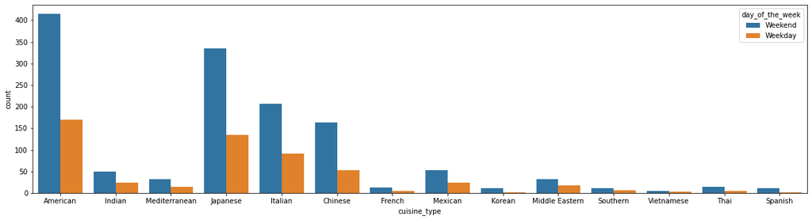

```python
# Lets have a visual representation of this by using the count plot
plt.figure(figsize = (20,5))
sns.countplot(data=df ,x= 'cuisine_type', hue='day_of_the_week')
plt.show()
```

#### Observations:

- We can see that the most popular cuisine on weekends is the American Cuisine with over 400 orders on weekends

### **Question 9**: What percentage of the orders cost more than 20 dollars? [2 marks]

```python
# Precentage of orders that cost more than $20

#first how many orders cost more than $20
count_more_than_20 = len(df[df['cost_of_the_order'] >20])

print(count_more_than_20, 'Orders cost more than $20')

#Then we calculate the percentage
More_than_20 = round(((count_more_than_20/df.shape[0]) *100),2)

print('The percentage of the orders that cost more than $20 is: ', More_than_20,'%')
```

```
555 Orders cost more than $20
The percentage of the orders that cost more than $20 is:  29.24 %
```

#### Observations:

The percentage of the orders that cost more than $20 is: **29.24 %**

### **Question 10**: What is the mean order delivery time? [1 mark]

```python
#using the .mean function on the delivery time column we have:
mean_del_time = round(df['delivery_time'].mean(),2)
print ('The mean order delivery time is', mean_del_time,'minutes')
```

```
The mean order delivery time is 24.16 minutes
```

#### Observations:

The mean Order delivery time is **24.16 minutes**

This can also be seen in our statistical summary above when we used 'df.describe()'

### **Question 11:** The company has decided to give 20% discount vouchers to the top 3 most frequent customers. Find the IDs of these customers and the number of orders they placed. [1 mark]

```python
# we can get this using the value count and head function
df['customer_id'].value_counts().head(3)
```

```
52832    13
47440    10
83287     9
Name: customer_id, dtype: int64
```

#### Observations:

The top 3 customer IDs are **52832**, **47440** and **83287** with **13**, **10** and **9** orders respectively

### **Question 12**: Perform a multivariate analysis to explore relationships between the important variables in the dataset. (It is a good idea to explore relations between numerical variables as well as relations between numerical and categorical variables) [10 marks]

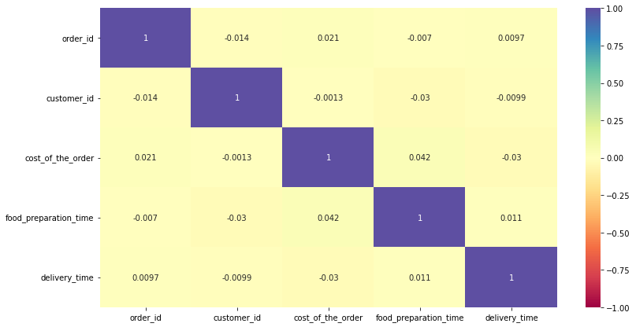

```python
#Corelation between all the variables using the heat map
plt.figure(figsize=(13,7))
sns.heatmap(df.corr(),annot=True,cmap='Spectral',vmin=-1,vmax=1)
plt.show()
```

### Observation

There is no significant correlation amongst the data variables

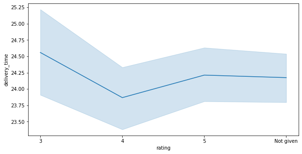

```python
#relationship between ratings and delivery time
plt.figure(figsize=(10, 5))
sns.lineplot(data = df, x = 'rating', y = 'delivery_time' )
plt.show()
```

### Observation

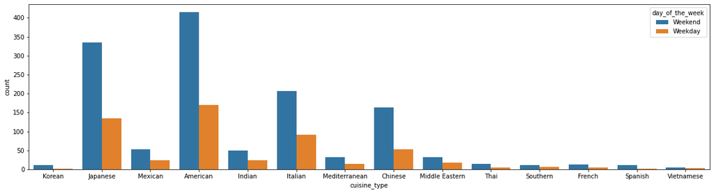

```python
#Comparing cuisine types, day of the week and number of orders
plt.figure(figsize = (20,5))
sns.countplot(data=df ,x= 'cuisine_type', hue='day_of_the_week')
plt.show()
```

### Observation

- More orders were made on weekends and weekdays for American , Japanese, Italian and Chinese cuisine

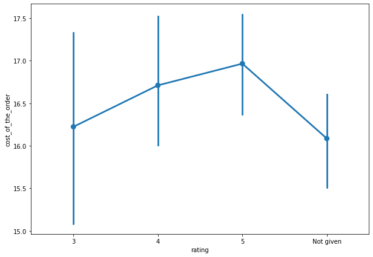

```python
# comparing ratings and cost of order

plt.figure(figsize=(10,7))
sns.pointplot(x = "rating", y = "cost_of_the_order", data = df)
plt.show()
```

### Observation

- Orders rated cost between 16 and 17 dollars

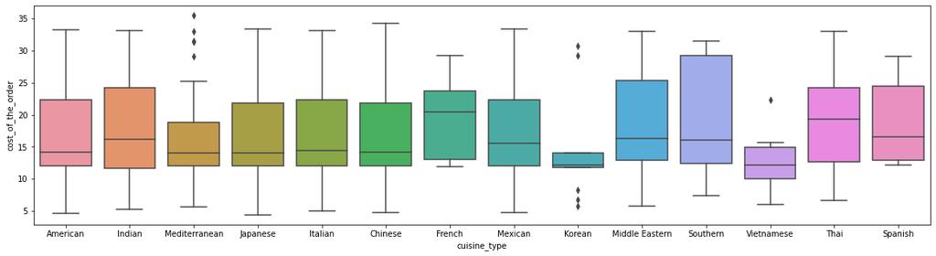

```python
#comparing cost of order and cuisine type

plt.figure(figsize = (20,5))
sns.boxplot(data=df ,y= 'cost_of_the_order', x='cuisine_type')
plt.show()
```

## Observation

Ther are outliers present in the box plot for Mediterranean, Korean and Vietnamese cuisine

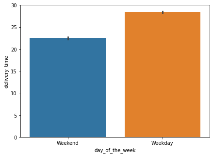

```python
#comparing delivery time  and day of the week
plt.figure(figsize = (7,5))
sns.barplot(data=df ,y= 'delivery_time', x='day_of_the_week')
plt.show()
```

### Observation

- Delivery is faster on weekends than on weekdays

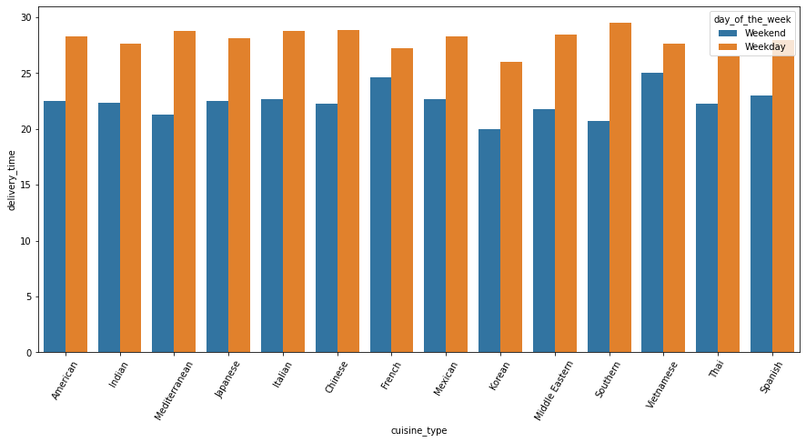

```python
#comparing delivery time, cuisine type and day of the week
plt.figure(figsize = (15,7))
sns.barplot(data=df ,y= 'delivery_time', x= 'cuisine_type', hue = 'day_of_the_week', ci= False)
plt.xticks(rotation = 60)
plt.show()
```

### Observation

- Korean cuisines have the lowest delivery time

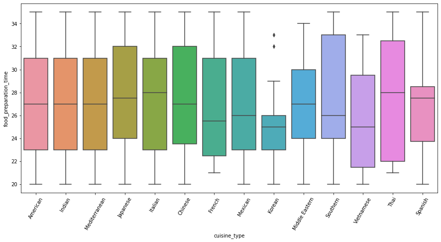

```python
# Comparing food preparation time and cuisine type
plt.figure(figsize=(15,7))
sns.boxplot(data= df, y='food_preparation_time', x= 'cuisine_type')
plt.show()
```

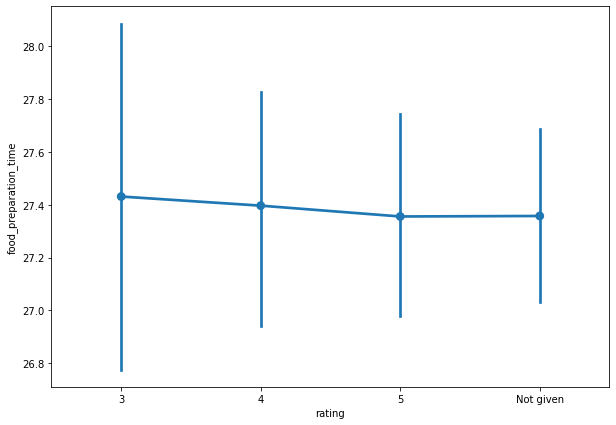

```python
# Relationship between rating and food preparation time
plt.figure(figsize=(10, 7))
sns.pointplot(x ='rating', y= 'food_preparation_time', data = df)
plt.show()
```

### Observation

Food preparation is not a factor considered by customers during rating

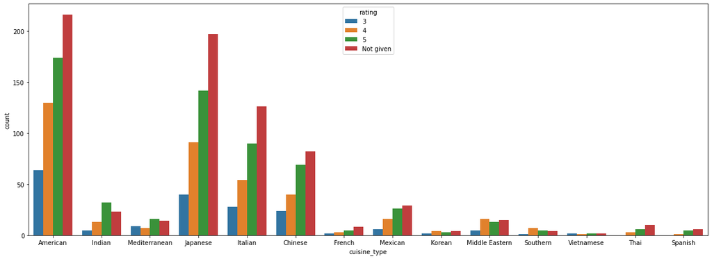

```python
# comparing cuisine type and Rating
plt.figure(figsize=(20, 7))
sns.countplot(x = 'cuisine_type', hue = 'rating', data = df)
plt.show()
```

### Observation

- American , Japanese , Italian and Chinese are the highest rated Cuisines

### **Question 13:** The company wants to provide a promotional offer in the advertisement of the restaurants. The condition to get the offer is that the restaurants must have a rating count of more than 50 and the average rating should be greater than 4. Find the restaurants fulfilling the criteria to get the promotional offer. [3 marks]

```python
#Filter the rating column for rated orders
new = df[df["rating"].isin(["3","4","5"])].copy()

#Convert the columns from object to integer
new['rating'] = pd.to_numeric(new['rating'])

# Create a dataframe that contains the restaurant names with their rating counts and mean ratings
avr_count_new = new.groupby('restaurant_name').agg({'rating': ['count', 'mean']})

#Label new colunm headers to make sorting easier and reset the index
avr_count_new.columns = ['ratings_count', 'ratings_mean']
avr_count_new = avr_count_new.reset_index()

#sort by rating count to get restaurants with ratings count above 50 and average rating of 4
avr_count_new = avr_count_new.sort_values(by= 'ratings_count' , ascending = False)
avr_count_new.head()
```

|  | restaurant_name | ratings_count | ratings_mean |
| --- | --- | --- | --- |
| 117 | Shake Shack | 133 | 4.28 |
| 132 | The Meatball Shop | 84 | 4.51 |
| 17 | Blue Ribbon Sushi | 73 | 4.22 |
| 16 | Blue Ribbon Fried Chicken | 64 | 4.33 |
| 104 | RedFarm Broadway | 41 | 4.24 |

#### Observations:

From the table, the Qualified restaurants are:

- Shake Shack
- The Meatball Shop
- Blue Ribbon Sushi
- Blue Ribbon Fried Chicken

### **Question 14:** The company charges the restaurant 25% on the orders having cost greater than 20 dollars and 15% on the orders having cost greater than 5 dollars. Find the net revenue generated by the company across all orders. [3 marks]

```python
#Write the apprpriate column name to compute the revenue

def cal_revenue(x):
    if x > 20:
        return x*0.25
    elif x > 5:
        return x*0.15
    else:
        return x*0

df['Net_Revenue'] = df['cost_of_the_order'].apply(cal_revenue)
df.head()
```

|  | order_id | customer_id | restaurant_name | cuisine_type | cost_of_the_order | day_of_the_week | rating | food_preparation_time | delivery_time | Net_Revenue |
| --- | --- | --- | --- | --- | --- | --- | --- | --- | --- | --- |
| 0 | 1477334 | 106968 | Blue Ribbon Fried Chicken | American | 29.20 | Weekend | 3 | 25 | 15 | 7.30 |
| 1 | 1477224 | 147468 | Tamarind TriBeCa | Indian | 25.22 | Weekday | 3 | 20 | 24 | 6.30 |
| 2 | 1477859 | 89574 | Barbounia | Mediterranean | 5.97 | Weekday | 3 | 33 | 30 | 0.90 |
| 3 | 1477449 | 104548 | Pylos | Mediterranean | 11.30 | Weekend | 3 | 24 | 23 | 1.70 |
| 4 | 1477760 | 130507 | Jack's Wife Freda | Mediterranean | 22.75 | Weekend | 3 | 35 | 29 | 5.69 |

```python
print('The total revenue generated is :',round(df['Net_Revenue'].sum(),2))
```

```
The total revenue generated is : 6166.3
```

#### Observations:

The Total revenue generated is **$6,166.30**

### **Question 15:** The company wants to analyze the total time required to deliver the food. What percentage of orders take more than 60 minutes to get delivered from the time the order is placed? (The food has to be prepared and then delivered.) [2 marks]

```python
# First we add the food preparation time and delivery time columns to get the total time and assign it to a new column

df['total_time'] = df['food_preparation_time'] + df['delivery_time']

Orders_Above_60mins = len(df[df['total_time'] >60]) # count of orders above 60mins in the new total time column

print('The count of total time for orders above 60mins is:',Orders_Above_60mins)

# Calculating the percentage of orders above 60mins
percentage = round(((Orders_Above_60mins/df.shape[0])*100),2) #add round function to reduce float to 2 decimal places
print('The Total time percentage for orders above 60mins is:',percentage,'%')
```

```
The count of total time for orders above 60mins is: 200
The Total time percentage for orders above 60mins is: 10.54 %
```

#### Observations:

The Total time percentage for orders above 60mins is: **10.54 %**

### **Question 16:** The company wants to analyze the delivery time of the orders on weekdays and weekends. How does the mean delivery time vary during weekdays and weekends? [2 marks]

```python
# Using the Groupby Function , get the average delivery time

round(df.groupby(df['day_of_the_week'])['delivery_time'].mean())
```

```
day_of_the_week
Weekday   28.00
Weekend   22.00
Name: delivery_time, dtype: float64
```

#### Observations:

The mean delivery time for weekdays is about **28 mins**

The mean delivery time for weekends is about **22 mins**

### Recommendations:

- The restaurants that experienced low patronage from customers can introduce promotional offers like discounts, first time customer offers, specific day of the week promotions, or even extra specials. These promotional offers can also be made available on the landing page of the food hub app to capture visiting customers interests.
- Food Hub can also look to increase the number of delivery personnels on week days to compensate for the higher delivery times during this period and assign them to trafic prone areas and restaurants with high patronage in order to reduce the delivery times. we will need location and traffic data to further explore this.
- For the unrated orders, customers should be encouraged to give feedbacks and share their reviews and also introduce surveys by backing rewarding them up with incentives and also introduce fun/interesting ways to do so. I feel the volume of unrated orders is enough to affect the data in such a way that more useful information can be obtained whan all these orders are rated. This can also further help the restaurants improve their services and increase patronage leading to increased demand for delivery.